# Mental Health Survey 2014

### Mental Health in Survey 2014

This dataset was produced by Open Sourcing Mental Health Illness (OSMI) in 2014. 1200 employee from the tech industry were asked 27 questions to **measure** the attitude towards mental health and the frequency of mental health disorders in the tech workplace.

In additon to demographic information, the following informatin were extracted:

- **Self-employed:** Whether the respondent is self-employed (Yes or No).
- **Family history:** Whether the respondent has a family history of mental health issues (Yes or No).
- **Treatment:** Whether the respondent has sought treatment for a mental health condition.
- **Work interference:** Whether mental health issues affect the respondent’s ability to perform work (Often, Sometimes, Rarely, or Never).
- **No. of employees:** The size of the company the respondent works for, categorized by ranges like 1-5, 6-25, 26-100, etc.
- **Remote work:** Whether the respondent works remotely (Yes, No, or Sometimes).
- **Tech company:** Whether the respondent works in a technology company (Yes or No).
- **Benefits:** Whether the company provides mental health benefits (Yes, No, or Don’t know).
- **Care options:** Whether the respondent knows about the care options for mental health in their company.
- **Wellness program:** Whether the company offers a wellness program (Yes, No, or Don’t know).
- **Seek help:** Whether the respondent would feel comfortable asking for time off due to a mental health issue.
- **Anonymity:** Whether the respondent believes anonymity is protected if they were to take advantage of mental health benefits.
- **Leave:** Whether the respondent thinks taking a mental health leave would negatively impact their career.
- **Mental health consequences:** Whether the respondent believes there are negative consequences at work for discussing mental health issues.
- **Physical health consequences:** Whether the respondent believes there are negative consequences at work for discussing physical health issues.
- **Coworkers:** Whether the respondent would discuss mental health issues with coworkers.
- **Supervisor:** Whether the respondent would discuss mental health issues with their supervisor.
- **Mental health interview:** Whether the respondent believes mental health would be a factor in hiring decisions.
- **Physical health interview:** Whether the respondent believes physical health would be a factor in hiring decisions.
- **Mental vs. physical health:** Whether the respondent feels their employer takes mental health as seriously as physical health.
- **Observed consequences:** Whether the respondent has observed or heard of negative consequences for someone discussing mental health in the workplace.
- **Comments:** Free-text responses where respondents can leave additional comments.

```python
import numpy as np
import pandas as pd
import matplotlib.pyplot as plt
import seaborn as sns
```

```python
data = pd.read_csv('survey.csv')
```

```python
data.head(3)
```

|  | Timestamp | Age | Gender | Country | state | self_employed | family_history | treatment | work_interfere | no_employees | ... | leave | mental_health_consequence | phys_health_consequence | coworkers | supervisor | mental_health_interview | phys_health_interview | mental_vs_physical | obs_consequence | comments |
| --- | --- | --- | --- | --- | --- | --- | --- | --- | --- | --- | --- | --- | --- | --- | --- | --- | --- | --- | --- | --- | --- |
| 0 | 2014-08-27 11:29 | 37 | Female | United States | IL | NaN | No | Yes | Often | 25-Jun | ... | Somewhat easy | No | No | Some of them | Yes | No | Maybe | Yes | No | NaN |
| 1 | 2014-08-27 11:29 | 44 | M | United States | IN | NaN | No | No | Rarely | More than 1000 | ... | Don't know | Maybe | No | No | No | No | No | Don't know | No | NaN |
| 2 | 2014-08-27 11:29 | 32 | Male | Canada | NaN | NaN | No | No | Rarely | 25-Jun | ... | Somewhat difficult | No | No | Yes | Yes | Yes | Yes | No | No | NaN |

3 rows × 27 columns

```python
data.columns
```

```
Index(['Timestamp', 'Age', 'Gender', 'Country', 'state', 'self_employed',
       'family_history', 'treatment', 'work_interfere', 'no_employees',
       'remote_work', 'tech_company', 'benefits', 'care_options',
       'wellness_program', 'seek_help', 'anonymity', 'leave',
       'mental_health_consequence', 'phys_health_consequence', 'coworkers',
       'supervisor', 'mental_health_interview', 'phys_health_interview',
       'mental_vs_physical', 'obs_consequence', 'comments'],
      dtype='object')
```

```python
data.shape
```

```
(1259, 27)
```

### 1. Data Cleaning

A) Does the data contain NaN, or missing values?  
B) Are data entry consistent?  
C) Are their outliers?  
D) Any invalid entries?

```python
# Checking of null values
data.isnull().sum()
```

```
Timestamp                       0
Age                             0
Gender                          0
Country                         0
state                         515
self_employed                  18
family_history                  0
treatment                       0
work_interfere                264
no_employees                    0
remote_work                     0
tech_company                    0
benefits                        0
care_options                    0
wellness_program                0
seek_help                       0
anonymity                       0
leave                           0
mental_health_consequence       0
phys_health_consequence         0
coworkers                       0
supervisor                      0
mental_health_interview         0
phys_health_interview           0
mental_vs_physical              0
obs_consequence                 0
comments                     1095
dtype: int64
```

The state, self-employed, inteference of mental health with work, and comments columns contain null values.

3/4th of the comments entry is null, and analysis would require language processing, so it will not be included here.

The other columns will also be disgarded in the analysis. Risk analysis using available data on "work interefere" can be done as a seperate task.

```python
#data.info()
```

```python
data.describe()
```

|  | Age |
| --- | --- |
| count | 1.259000e+03 |
| mean | 7.942815e+07 |
| std | 2.818299e+09 |
| min | -1.726000e+03 |
| 25% | 2.700000e+01 |
| 50% | 3.100000e+01 |
| 75% | 3.600000e+01 |
| max | 1.000000e+11 |

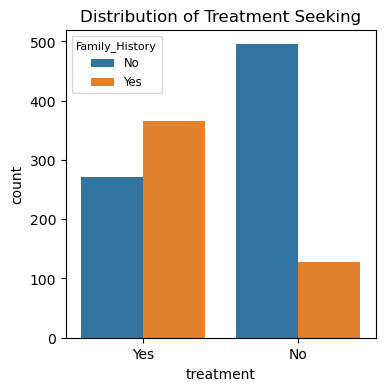

```python
plt.figure(figsize=(4,4))
sns.countplot(x='treatment', data=data, hue='family_history')
plt.title('Distribution of Treatment Seeking')
plt.legend(title='Family_History', title_fontsize=8, fontsize='small')
plt.show()
```

```python
# delete outliers in age

data= data[(data['Age'] >= 18) & (data['Age'] <= 85)]
```

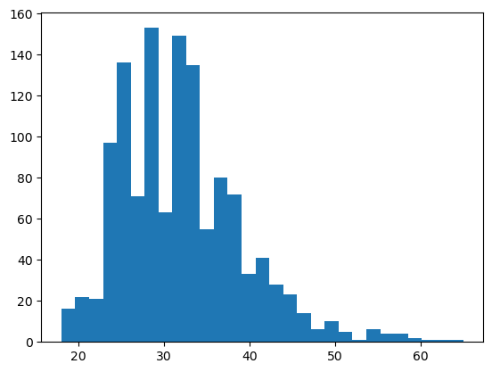

```python
plt.hist(data['Age'], bins = 'auto');
```

```python
# inconsistency in data entry and invalid entries
data['Gender'].value_counts()
```

```
Gender
Male                                              612
male                                              204
Female                                            120
M                                                 116
female                                             62
F                                                  38
m                                                  34
f                                                  15
Make                                                4
Woman                                               3
Male                                                3
Female                                              2
Cis Male                                            2
Man                                                 2
Female (trans)                                      2
Malr                                                1
Trans woman                                         1
male leaning androgynous                            1
Cis Man                                             1
Neuter                                              1
msle                                                1
cis male                                            1
queer                                               1
Female (cis)                                        1
cis-female/femme                                    1
Mail                                                1
femail                                              1
Guy (-ish) ^_^                                      1
Enby                                                1
Agender                                             1
Male (CIS)                                          1
Male-ish                                            1
maile                                               1
Trans-female                                        1
Cis Female                                          1
something kinda male?                               1
Mal                                                 1
queer/she/they                                      1
Androgyne                                           1
non-binary                                          1
Femake                                              1
woman                                               1
Nah                                                 1
fluid                                               1
Genderqueer                                         1
ostensibly male, unsure what that really means      1
Name: count, dtype: int64
```

```python
data['Gender'] = data['Gender'].replace(['male', 'm', 'M'], 'Male')
data['Gender'] = data['Gender'].replace(['female', 'f', 'F', 'woman'], 'Female')

data = data[(data['Gender'] == 'Female') | (data['Gender'] == 'Male')]
```

```python
data['Gender'].value_counts(normalize=True)*100
```

```
Gender
Male      80.299252
Female    19.700748
Name: proportion, dtype: float64
```

Since gender is imbalanced in the dataset, I would not include it in the modeling step to avoid allowing the model mistakenly attribute mental health problems with gender.

```python
data['Country'].value_counts()
```

```
Country
United States             714
United Kingdom            176
Canada                     68
Germany                    43
Ireland                    27
Netherlands                27
Australia                  21
France                     13
India                      10
New Zealand                 8
Poland                      7
Switzerland                 7
Sweden                      7
South Africa                6
Brazil                      6
Belgium                     6
Italy                       5
Israel                      5
Bulgaria                    4
Singapore                   4
Austria                     3
Mexico                      3
Finland                     3
Croatia                     2
Portugal                    2
Colombia                    2
Denmark                     2
Greece                      2
Russia                      2
Thailand                    1
Georgia                     1
Moldova                     1
China                       1
Czech Republic              1
Norway                      1
Romania                     1
Nigeria                     1
Japan                       1
Hungary                     1
Bosnia and Herzegovina      1
Uruguay                     1
Spain                       1
Latvia                      1
Costa Rica                  1
Slovenia                    1
Philippines                 1
Name: count, dtype: int64
```

**USA vs. the Whole Dataset**  
I want to create a second dataframe containing responnts from USA only. I'm interested to see if the statistics of some answers differ in USA vs. the whole dataset.

```python
USA= data[data['Country'] == 'United States']
USA.shape
```

[output not shown]

```python
USA.columns
```

```
Index(['Timestamp', 'Age', 'Gender', 'Country', 'state', 'self_employed',
       'family_history', 'treatment', 'work_interfere', 'no_employees',
       'remote_work', 'tech_company', 'benefits', 'care_options',
       'wellness_program', 'seek_help', 'anonymity', 'leave',
       'mental_health_consequence', 'phys_health_consequence', 'coworkers',
       'supervisor', 'mental_health_interview', 'phys_health_interview',
       'mental_vs_physical', 'obs_consequence', 'comments'],
      dtype='object')
```

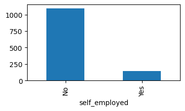

```python
data['self_employed'].value_counts().plot(kind='bar', figsize=(4,2));
```

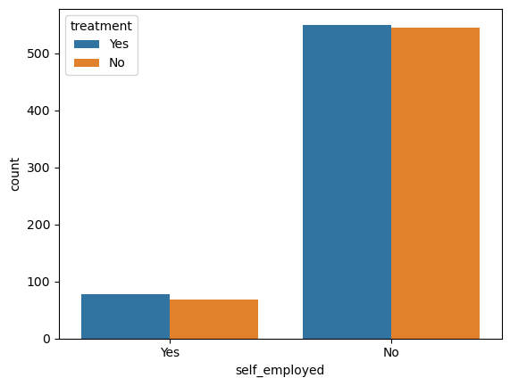

```python
sns.countplot(x='self_employed', data=data, hue='treatment')
```

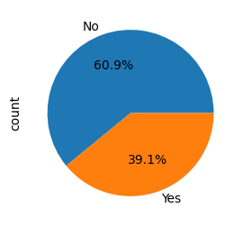

```python
data['family_history'].value_counts().plot(kind='pie', autopct='%1.1f%%', figsize = (3,3));
```

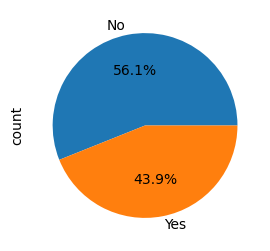

```python
USA['family_history'].value_counts().plot(kind='pie', autopct='%1.1f%%', figsize = (3,3));
```

```python
data['treatment'].value_counts(normalize=True)*100
```

```
treatment
Yes    50.595711
No     49.404289
Name: proportion, dtype: float64
```

```python
USA['treatment'].value_counts(normalize=True)*100
```

```
treatment
Yes    54.593875
No     45.406125
Name: proportion, dtype: float64
```

- ~ 40% of respondents have a family member with mental health condition.
- 50% of respondents has sought treatment for a mental health condition, 54% of USA respondents.

```python
# What percentage of those who sought treatment have a family history of mental health disorders.
fam_person = USA[(USA['treatment'] == 'Yes') & (USA['family_history'] == 'Yes')]
percentage = (len(fam_person)/len(USA[USA['treatment'] == 'Yes'])) * 100
print(f"Percent of those who sought treatment also have family history of mental health: {percentage:0.2f}%")
```

```
Percent of those who sought treatment also have family history of mental health: 61.03%
```

```python
# What percentage of those reported not seeking treatment, have a family history of mental health disorder

his_no = USA[(USA['treatment'] == 'No') & (USA['family_history'] == 'Yes')]
percentage = (len(his_no)/len(USA[USA['treatment'] == 'No'])) * 100
print(f"Percent of those who didn't seek treatment have a family history of mental health: {percentage:0.2f}%")
```

```
Percent of those who didn't seek treatment have a family history of mental health: 23.46%
```

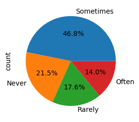

```python
data['work_interfere'].value_counts().plot(kind='pie', autopct='%1.1f%%', figsize = (3,3));
```

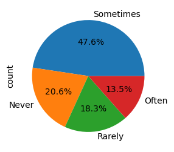

```python
USA['work_interfere'].value_counts().plot(kind='pie', autopct='%1.1f%%', figsize = (3,3));
```

```python
data['remote_work'].value_counts()
```

```
remote_work
No     850
Yes    361
Name: count, dtype: int64
```

```python
USA['remote_work'].value_counts()
```

```
remote_work
No     513
Yes    238
Name: count, dtype: int64
```

```python
data['tech_company'].value_counts(normalize=True)*100
```

```
tech_company
Yes    81.878637
No     18.121363
Name: proportion, dtype: float64
```

```python
# 18% percent of employee are not in a tech company
```

```python
USA['tech_company'].value_counts(normalize=True)*100
```

```
tech_company
Yes    81.258741
No     18.741259
Name: proportion, dtype: float64
```

```python
# create a dataframe containing only those who sought treatemtn
positive = data[data['treatment'] == 'Yes']
positive.shape
```

```
(604, 27)
```

Around 20% of the respondents are not from the tech workplace!

For me, it doesn't matter. I'm analysing employees. If the question is specific to tech workplace, then they need to be removed from the data.

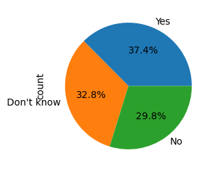

```python
data['benefits'].value_counts().plot(kind='pie', autopct='%1.1f%%', figsize = (3,3));
```

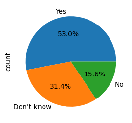

```python
USA['benefits'].value_counts().plot(kind='pie', autopct='%1.1f%%', figsize = (3,3));
```

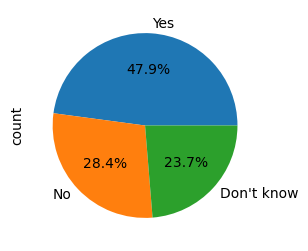

```python
positive['benefits'].value_counts().plot(kind='pie', autopct='%1.1f%%', figsize = (3,3));
```

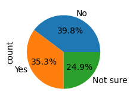

```python
data['care_options'].value_counts().plot(kind='pie', autopct='%1.1f%%', figsize = (2,2));
```

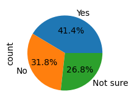

```python
USA['care_options'].value_counts().plot(kind='pie', autopct='%1.1f%%', figsize = (2,2));
```

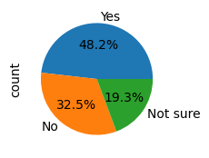

```python
positive['care_options'].value_counts().plot(kind='pie', autopct='%1.1f%%', figsize = (2,2));
```

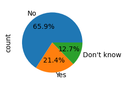

```python
positive['wellness_program'].value_counts().plot(kind='pie', autopct='%1.1f%%', figsize = (2,2));
```

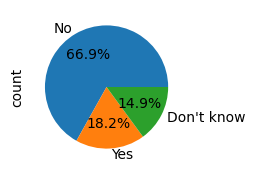

```python
data['wellness_program'].value_counts().plot(kind='pie', autopct='%1.1f%%', figsize = (2,2));
```

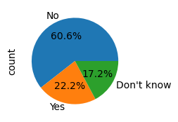

```python
USA['wellness_program'].value_counts().plot(kind='pie', autopct='%1.1f%%', figsize = (2,2));
```

- Only about 20% of companies offer wellness programs!

```python
data.columns
```

```
Index(['Timestamp', 'Age', 'Gender', 'Country', 'state', 'self_employed',
       'family_history', 'treatment', 'work_interfere', 'no_employees',
       'remote_work', 'tech_company', 'benefits', 'care_options',
       'wellness_program', 'seek_help', 'anonymity', 'leave',
       'mental_health_consequence', 'phys_health_consequence', 'coworkers',
       'supervisor', 'mental_health_interview', 'phys_health_interview',
       'mental_vs_physical', 'obs_consequence', 'comments'],
      dtype='object')
```

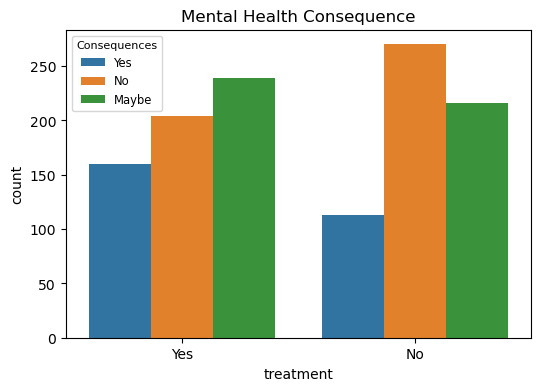

```python
plt.figure(figsize=(6,4))
custom_order=['Yes', 'No', 'Maybe']
sns.countplot(x='treatment', data=data, hue='mental_health_consequence', hue_order=custom_order)
plt.title('Mental Health Consequence')
plt.legend(title='Consequences', title_fontsize=8, fontsize='small')
plt.show()
```

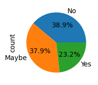

```python
data['mental_health_consequence'].value_counts().plot(kind='pie', autopct='%1.1f%%', figsize=(2,2))
```

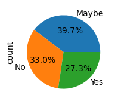

```python
positive['mental_health_consequence'].value_counts().plot(kind='pie', autopct='%1.1f%%', figsize=(2,2))
```

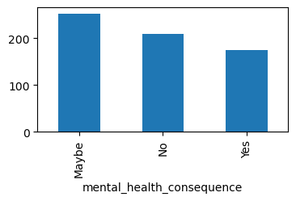

```python
positive['mental_health_consequence'].value_counts().plot(kind='bar', figsize=(4,2));
```

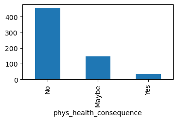

```python
positive['phys_health_consequence'].value_counts().plot(kind='bar', figsize=(4,2));
```

```python
data['coworkers'].value_counts(normalize=True)*100
```

```
coworkers
Some of them    61.477363
No              20.651311
Yes             17.871326
Name: proportion, dtype: float64
```

```python
positive['coworkers'].value_counts(normalize=True)*100
```

```
coworkers
Some of them    61.224490
Yes             20.094192
No              18.681319
Name: proportion, dtype: float64
```

```python
USA['anonymity'].value_counts(normalize=True)*100
```

```
anonymity
Don't know    66.204986
Yes           31.301939
No             2.493075
Name: proportion, dtype: float64
```

```python
positive['supervisor'].value_counts(normalize=True)*100
```

```
supervisor
Yes             39.246468
No              32.496075
Some of them    28.257457
Name: proportion, dtype: float64
```

- While only *20%* of those who sought help would talk to coworkers about mental health, *40* would talk to a supervisor

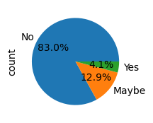

```python
positive['mental_health_interview'].value_counts().plot(kind='pie', autopct='%1.1f%%', figsize=(2,2))
```

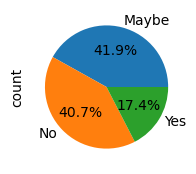

```python
positive['phys_health_interview'].value_counts().plot(kind='pie', autopct='%1.1f%%', figsize=(2,2))
```

- 80% of those with mental health do not think that mental health would be a factor in the decision
- Physical health may be a bigger obsticle in hiring decisions

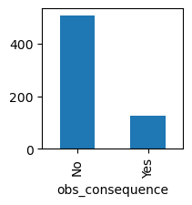

```python
positive['obs_consequence'].value_counts().plot(kind='bar', figsize=(2,2))
```

```python
data['no_employees'].value_counts()
```

[output not shown]

```python
data['no_employees']= data['no_employees'].replace('25-Jun', '6-25')
data['no_employees']= data['no_employees'].replace('05-Jan', '1-5')
data['no_employees']= data['no_employees'].replace('More than 1000', '1000-1100')
data['no_employees'].value_counts()
```

```
no_employees
6-25         277
26-100       274
1000-1100    272
100-500      168
1-5          154
500-1000      58
Name: count, dtype: int64
```

### Feature Engineering

```python
# selecting the features I want to include

data = data[['family_history', 'treatment', 'no_employees', 'tech_company', 'benefits',
       'wellness_program', 'seek_help', 'anonymity', 'leave',
       'mental_health_consequence', 'phys_health_consequence', 'coworkers',
       'supervisor', 'mental_health_interview', 'phys_health_interview',
       'mental_vs_physical', 'obs_consequence']]
```

```python
data.shape
```

```
(1203, 17)
```

**Create a New Feature**  
Create workplace support score: combining data on mental health benefits, wellness programs, and anonymity protection to score workplace supportiveness.

```python
# Replace 'yes', 'no', and 'maybe' with 1, 0, and 0.5
#df_numeric = data[['benefits', 'anonymity', 'wellness_program', 'seek_help']].replace({'yes': 1, 'no': 0, 'maybe': 0.5})

# Create a new feature by summing the converted values
#df_numeric['new_feature'] = df_numeric[['benefits', 'anonymity', 'wellness_program', 'seek_help']].sum(axis=1)
```

```python
df_numeric.head(3)
```

|  | benefits | anonymity | wellness_program | seek_help | new_feature |
| --- | --- | --- | --- | --- | --- |
| 0 | Yes | Yes | No | Yes | YesYesNoYes |
| 1 | Don't know | Don't know | Don't know | Don't know | Don't knowDon't knowDon't knowDon't know |
| 2 | No | Don't know | No | No | NoDon't knowNoNo |

```python
data.loc[:, 'support_score'] = data[['benefits', 'anonymity', 'wellness_program', 'seek_help']].apply(lambda x: (x == 'Yes').sum(), axis=1)
#data['support_score'] = data[['benefits', 'anonymity', 'wellness_program']].eq('Yes').sum(axis=1)
```

```python
data['support_score'].head()
```

```
0    3
1    0
2    0
3    0
4    1
Name: support_score, dtype: int64
```

```python
data['support_score'].value_counts()
```

```
support_score
0    571
1    283
2    160
3     97
4     92
Name: count, dtype: int64
```

```python
print(data[['benefits', 'anonymity', 'wellness_program']].head())
```

```
     benefits   anonymity wellness_program
0         Yes         Yes               No
1  Don't know  Don't know       Don't know
2          No  Don't know               No
3          No          No               No
4         Yes  Don't know       Don't know
```

```python
USA['no_employees'].value_counts()
```

[output not shown]

Convert No. of employees into categorical variable reflecting company size.

```python
# Binning company size into categories
bins = [0, 5, 25, 100, 500, 1000, 5000, 10000]
labels = ['1-5', '6-25', '26-100', '101-500', '501-1000', '1001-5000', '5001+']
data['Company_size_category'] = pd.cut(data['No. of employees'], bins=bins, labels=labels)
```

[output not shown]

```python
data.head()
```

[output not shown]

```python
### Save cleaned data to a new csv file ###

data.to_csv('cleaned_mental.csv', index=False)

#USA.to_csv('cleaned_USA_mental.csv', index=False)
```

### Segmentation Analysis

[figure not shown]

```python
# Group by company size and calculate the proportion of those with mental health benefits
company_support = data.groupby('no_employees')['benefits'].value_counts(normalize=True).unstack().fillna(0)
#company_size
# Plot the data
plt.figure(figsize=(10,8))
company_support.plot(kind='bar', stacked=True, color=['lightgreen', 'purple', 'orange'], edgecolor='black')
plt.title('Availability of Mental Health Benefits by Company Size')
plt.xlabel('Company Size')
plt.ylabel('Proportion')
plt.legend(title='Mental Health Benefits', labels=['No', 'Yes', 'Maybe'])
plt.xticks(rotation=45)
plt.tight_layout()
plt.show()
```

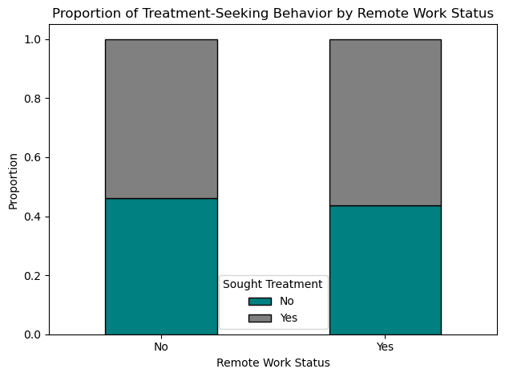

```python
# Group by remote work status and calculate the proportion of individuals who sought treatment
remote_treatment = USA.groupby('remote_work')['treatment'].value_counts(normalize=True).unstack().fillna(0)

# Plot the data
plt.figure(figsize=(8, 6))
remote_treatment.plot(kind='bar', stacked=True, color=['teal', 'gray'], edgecolor='black')
plt.title('Proportion of Treatment-Seeking Behavior by Remote Work Status')
plt.xlabel('Remote Work Status')
plt.ylabel('Proportion')
plt.legend(title='Sought Treatment', labels=['No', 'Yes'])
plt.xticks(rotation=0)
plt.tight_layout()
plt.show()
```

Perform detailed exploratory data analysis to understand relationships between variables.

Key Analyses: Compare treatment-seeking behavior by gender, age, company size, and family history. Analyze how workplace support correlates with treatment and work interference. Explore how remote work affects mental health issues.

```python
# Treatment by gender
sns.countplot(x='Gender', hue='Treatment', data=data)
plt.title('Treatment Seeking by Gender')
plt.show()

# Workplace support vs. treatment seeking
sns.barplot(x='support_score', y='Treatment', data=data, estimator=lambda x: len(x) / len(data) * 100)
plt.title('Workplace Support vs. Treatment Seeking')
plt.ylabel('Percentage')
plt.show()
```

[output not shown]

[output cut: 28 more lines]

[output not shown]

Depending on your project goal, you could perform statistical testing or build machine learning models.

Options: Logistic Regression: Predict whether an individual will seek treatment based on variables like gender, age, family history, and workplace support. Chi-Square Test: Assess the relationship between categorical variables (e.g., gender and treatment). Decision Trees or Random Forests: Build models to classify individuals who are likely to seek mental health treatment.

```python
from sklearn.model_selection import train_test_split
from sklearn.linear_model import LogisticRegression
from sklearn.metrics import classification_report

# Select features and target variable
X = data[['Age', 'Gender', 'family_history', 'support_score']]
X = pd.get_dummies(X, drop_first=True)  # Convert categorical data to numerical
y = data['Treatment'].apply(lambda x: 1 if x == 'Yes' else 0)

# Train-test split
X_train, X_test, y_train, y_test = train_test_split(X, y, test_size=0.2, random_state=42)

# Logistic Regression
model = LogisticRegression()
model.fit(X_train, y_train)

# Predictions and evaluation
y_pred = model.predict(X_test)
print(classification_report(y_test, y_pred))
```

```python
Create plots showing relationships between factors like gender, company size, and treatment.
Summarize which factors most influence mental health outcomes in the tech industry.
Draw actionable insights: What can companies do to improve mental health support for employees?
```

```python
USA.shape
```

```
(751, 27)
```

```python
USA.columns
```

```
Index(['Timestamp', 'Age', 'Gender', 'Country', 'state', 'self_employed',
       'family_history', 'treatment', 'work_interfere', 'no_employees',
       'remote_work', 'tech_company', 'benefits', 'care_options',
       'wellness_program', 'seek_help', 'anonymity', 'leave',
       'mental_health_consequence', 'phys_health_consequence', 'coworkers',
       'supervisor', 'mental_health_interview', 'phys_health_interview',
       'mental_vs_physical', 'obs_consequence', 'comments'],
      dtype='object')
```

```python
USA['family_history'].value_counts()
```

```
family_history
No     421
Yes    330
Name: count, dtype: int64
```

```python
data['family_history'].value_counts()
```

```
family_history
No     767
Yes    492
Name: count, dtype: int64
```

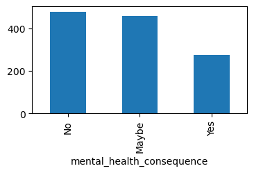

```python
data['mental_health_consequence'].value_counts().plot(kind='bar', figsize=(4,2))
```

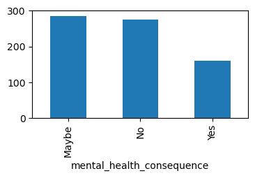

```python
USA['mental_health_consequence'].value_counts().plot(kind='bar', figsize=(4,2));
```

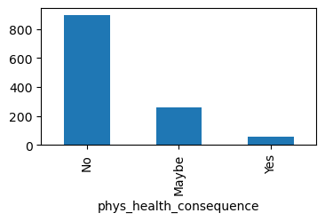

```python
data['phys_health_consequence'].value_counts().plot(kind='bar', figsize=(4,2));
```

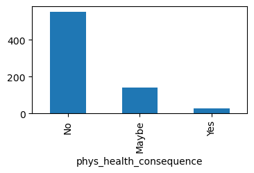

```python
USA['phys_health_consequence'].value_counts().plot(kind='bar', figsize=(4,2));
```

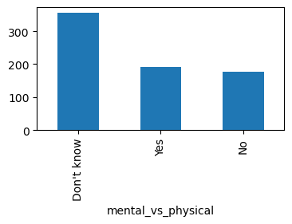

```python
USA['mental_vs_physical'].value_counts().plot(kind='bar', figsize=(4,2));
```

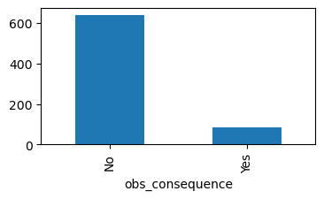

```python
USA['obs_consequence'].value_counts().plot(kind='bar', figsize=(4,2));
```

```python
data['benefits'].value_counts()
```

```
benefits
Yes           454
Don't know    396
No            361
Name: count, dtype: int64
```

```python
data['leave'].value_counts(normalize=True)
```

```
leave
Don't know            0.451693
Somewhat easy         0.210570
Very easy             0.164327
Somewhat difficult    0.097440
Very difficult        0.075970
Name: proportion, dtype: float64
```

```python
USA['leave'].value_counts(normalize=True)
```

```
leave
Don't know            0.518006
Somewhat easy         0.184211
Very easy             0.142659
Somewhat difficult    0.087258
Very difficult        0.067867
Name: proportion, dtype: float64
```

```python
USA_help = USA[USA['treatment'] == 'Yes']
USA_help['remote_work'].value_counts(normalize=True)*100
```

```
remote_work
No     67.258883
Yes    32.741117
Name: proportion, dtype: float64
```

```python
USA_help['work_interfere'].value_counts(normalize=True)*100
```

```
work_interfere
Sometimes    57.506361
Rarely       20.356234
Often        17.557252
Never         4.580153
Name: proportion, dtype: float64
```

```python
USA_help['Gender'].value_counts(normalize=True)*100
```

```
Gender
Male      68.781726
Female    31.218274
Name: proportion, dtype: float64
```

```python
USA['Gender'].value_counts(normalize=True)*100
```

```
Gender
Male      76.454294
Female    23.545706
Name: proportion, dtype: float64
```

Discussion:

Issues with this dataset:

- The dataset is small.
- While 50% of respondant seeked treatment, gender impalance in data may weight being a male as a contributer to mental health problems.